# Class 15: Bootstrapping

Andrew Lampinen

February 11th, 2019

# 15 Bootstrapping

## 15.1 Load packages and set plotting theme

```r
library(tidyverse)
library(boot)
library(patchwork)

# include references for used packages
knitr::write_bib(.packages(), "packages.bib")
```

```r
theme_set(
  theme_classic() #set the theme
)
```

## 15.2 What’s wrong with parametric tests?

### 15.2.1 T-tests on non-normal distributions

Let’s see some examples! One common non-normal distribution is the *log-normal* distribution, i.e. a distribution that is normal after you take its logarithm. Many natural processes have distributions like this. One of particular interest to us is reaction times.

```r
num_points = 1e4
parametric_plotting_data = data.frame(distribution = rep(c("Normal", "Log-normal"), each=num_points),
                                      value = c(rnorm(num_points, 0, 1),  # normal
                                                exp(rnorm(num_points, 0, 1)) - exp(1/2))) %>%
  mutate(distribution=factor(distribution, levels=c("Normal", "Log-normal")))
```

Let’s see how violating the assumption of normality changes the results of `t.test`. We’ll compare two situations

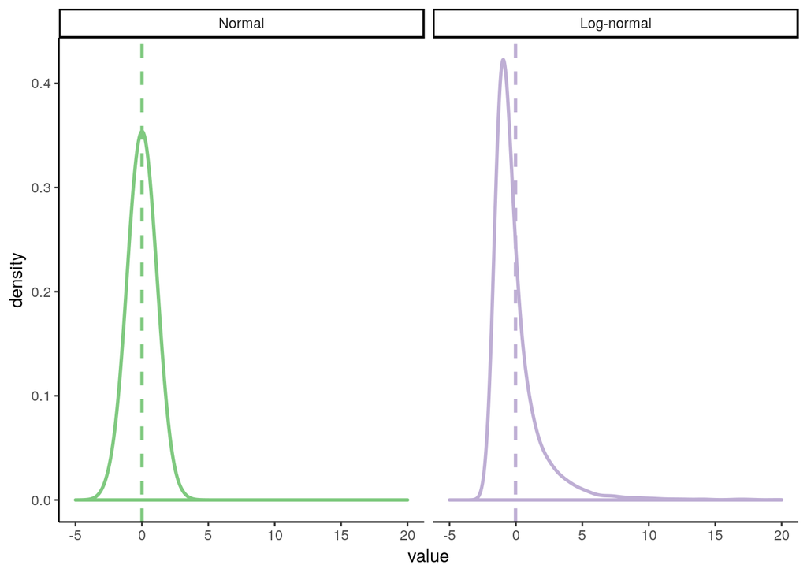

```r
ggplot(parametric_plotting_data, aes(x=value, color=distribution)) +
  geom_density(bw=0.5, size=1) +
  geom_vline(data=parametric_plotting_data %>%
               group_by(distribution) %>%
               summarize(mean_value = mean(value), sd_value = sd(value)),
             aes(xintercept=mean_value, color=distribution),
             linetype=2, size=1) +
  xlim(-5, 20) +
  facet_grid(~ distribution, scales="free") +
  guides(color=F) +
  scale_color_brewer(palette="Accent")
```

```r
ggsave("figures/log_normal_dists.png", width=5, height=3)
gen_data_and_test = function(num_observations_per) {
x = rnorm(num_observations_per, 0, 1.1)
y = rnorm(num_observations_per, 0, 1.1)

pnormal = t.test(x, y, var.equal=T)$p.value

# what if the data are log-normally distributed?
x = exp(rnorm(num_observations_per, 0, 1.1))
y = exp(rnorm(num_observations_per, 0, 1.1))

pnotnormal = t.test(x, y, var.equal=T)$p.value
return(c(pnormal, pnotnormal))
}

parametric_issues_demo = function(num_tests, num_observations_per) {
  replicate(num_tests, gen_data_and_test(num_observations_per))
}
```

```r
set.seed(0) # ensures we get the same results each time we run it

num_tests = 1000 # how many datasets to generate/tests to run
num_observations_per = 20 # how many obsservations in each dataset

parametric_issues_results = parametric_issues_demo(num_tests=num_tests,
                                                   num_observations_per=num_observations_per)




parametric_issues_d = data.frame(valid_tests = parametric_issues_results[1,],
                                 invalid_tests = parametric_issues_results[2,],
                                 iteration=1:num_tests) %>%
  gather(type, p_value, contains("tests")) %>%
  mutate(is_significant = p_value < 0.05)

# Number significant results with normally distributed data
sum(parametric_issues_results[1,] < 0.05)

# number of significant results with log-normally distributed data
sum(parametric_issues_results[2,] < 0.05)
```

```
[1] 41
[1] 25
```

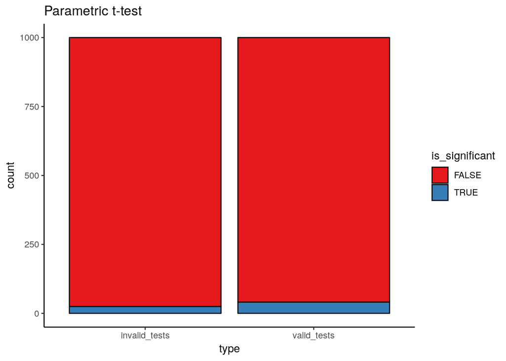

```r
ggplot(parametric_issues_d, aes(x=type, fill=is_significant)) +
  geom_bar(stat="count", color="black") +
  scale_fill_brewer(palette="Set1") +
  labs(title="Parametric t-test")
```

That’s a non-trivial reduction in power from a misspecified model! (~80% to ~54%).

```r
boot_mean_diff_test = function(x, y) {
  obs_t = t.test(x, y)$statistic
  boot_iterate = function(x, y, indices) { # indices is a dummy here
    x_samp = sample(x,
                    length(x),
                    replace=T)
    y_samp = sample(y,
                    length(y),
                    replace=T)
    mean_diff = mean(y_samp) - mean(x_samp)
    return(mean_diff)
  }
  boots = boot(data = c(x, y), boot_iterate, R=500)
#  boots = replicate(100, boot_iterate(x, y))
#  quants = quantile(boots, probs=c(0.025, 0.975))
  quants = boot.ci(boots)$bca[4:5]
  return(sign(quants[1]) == sign(quants[2]))

}
```

(Omitted because with these small sample sizes bootstrapping is problematic – permutations are better)

```r
# gen_data_and_boot_test = function(num_observations_per) {
# x = rnorm(num_observations_per, 0, 1.1)
# y = rnorm(num_observations_per, 0, 1.1)
#
# pnormal = boot_mean_diff_test(x, y)
#
# # what if the data are log-normally distributed?
# x = exp(rnorm(num_observations_per, 0, 1.1))
# y = exp(rnorm(num_observations_per, 1, 1.1))
#
# pnotnormal = boot_mean_diff_test(x, y)
# return(c(pnormal, pnotnormal))
# }
#
# boot_results = replicate(num_tests, gen_data_and_boot_test(num_observations_per))
# sum(boot_results[1,])
# sum(boot_results[2,])
```

While the bootstrap **actually loses power** relative to a perfectly specified model, it is much more **robust** to changes in the assumptions of that model, and so it **retains more power when assumptions are violated**.

```r
perm_mean_diff_test = function(x, y) {
  obs_t = t.test(x, y)$statistic
  combined_data = c(x, y)
  n_combined = length(combined_data)
  n_x = length(x)
  perm_iterate = function(x, y) {
    perm = sample(n_combined)
    x_samp = combined_data[perm[1:n_x]]
    y_samp = combined_data[perm[-(1:n_x)]]
    this_t = t.test(x_samp, y_samp)$statistic
    return(this_t)
  }
  perms = replicate(500, perm_iterate(x, y))
  quants = quantile(perms, probs=c(0.025, 0.975))
  return(obs_t < quants[1] | obs_t > quants[2])
}
```

```r
# this could be much more efficient
gen_data_and_norm_and_perm_test = function(num_observations_per) {
  d = data.frame(distribution=c(),
                 null_true=c(),
                 parametric=c(),
                 permutation=c())

  # normally distributed
  ## null
  x = rnorm(num_observations_per, 0, 1.1)
  y = rnorm(num_observations_per, 0, 1.1)

  sig_par = t.test(x, y)$p.value < 0.05
  sig_perm = perm_mean_diff_test(x, y)
  d = bind_rows(d,
                data.frame(distribution="Normal",
                           null_true=T,
                           parametric=sig_par,
                           permutation=sig_perm))

  ## non-null
  x = rnorm(num_observations_per, 0, 1.1)
  y = rnorm(num_observations_per, 1, 1.1)

  sig_par = t.test(x, y)$p.value < 0.05
  sig_perm = perm_mean_diff_test(x, y)
  d = bind_rows(d,
                data.frame(distribution="Normal",
                           null_true=F,
                           parametric=sig_par,
                           permutation=sig_perm))

  # what if the data are log-normally distributed?
  ## null
  x = exp(rnorm(num_observations_per, 0, 1.1))
  y = exp(rnorm(num_observations_per, 0, 1.1))

  sig_par = t.test(x, y)$p.value < 0.05
  sig_perm = perm_mean_diff_test(x, y)
  d = bind_rows(d,
                data.frame(distribution="Log-normal",
                           null_true=T,
                           parametric=sig_par,
                           permutation=sig_perm))

  ## non-null
  x = exp(rnorm(num_observations_per, 0, 1.1))
  y = exp(rnorm(num_observations_per, 1, 1.1))

  sig_par = t.test(x, y)$p.value < 0.05
  sig_perm = perm_mean_diff_test(x, y)
  d = bind_rows(d,
                data.frame(distribution="Log-normal",
                           null_true=F,
                           parametric=sig_par,
                           permutation=sig_perm))

  return(d)
}

perm_results = replicate(num_tests, gen_data_and_norm_and_perm_test(num_observations_per),
                         simplify=F) %>%
  bind_rows()
```

```r
perm_results = perm_results %>%
  gather(test_type, significant, parametric, permutation) %>%
  mutate(distribution=factor(distribution, levels=c("Normal", "Log-normal")),
         null_true=ifelse(null_true,
                          "Null True",
                          "Alternative True"))
```

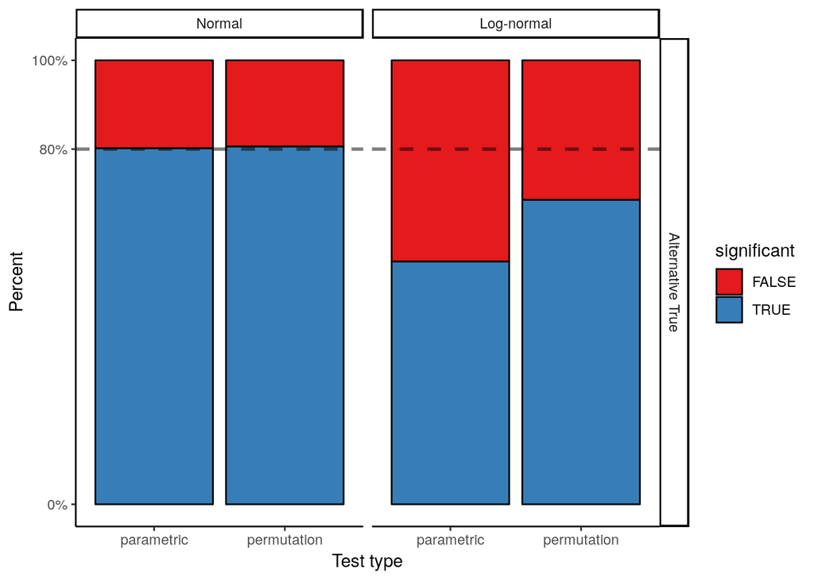

```r
ggplot(perm_results %>%
         filter(null_true == "Alternative True"), aes(x=test_type, fill=significant)) +
  geom_bar(stat="count", color="black") +
  scale_fill_brewer(palette="Set1") +
  facet_grid(null_true ~ distribution) +
  geom_hline(data=data.frame(null_true="Alternative True",
                        alpha=num_tests*0.8),
             mapping=aes(yintercept=alpha),
             linetype=2,
             size=1,
             alpha=0.5) +
  labs(x = "Test type", y = "Percent") +
  scale_y_continuous(breaks = c(0, 0.8, 1)*num_tests,
                     labels = paste(c(0, 80, 100), "%", sep=""))
```

```r
ggsave("figures/perm_test.png", width=5, height=3)
```

```r
perm_results %>%
  group_by(test_type, distribution, null_true) %>%
  summarize(pct_significant = sum(significant)/n())
```

```
# A tibble: 8 x 4
# Groups:   test_type, distribution [?]
  test_type   distribution null_true        pct_significant
  <chr>       <fct>        <chr>                      <dbl>
1 parametric  Normal       Alternative True           0.802
2 parametric  Normal       Null True                  0.051
3 parametric  Log-normal   Alternative True           0.547
4 parametric  Log-normal   Null True                  0.04
5 permutation Normal       Alternative True           0.806
6 permutation Normal       Null True                  0.047
7 permutation Log-normal   Alternative True           0.686
8 permutation Log-normal   Null True                  0.058
```

### 15.2.2 Non-IID noise and linear models

```r
num_points = 500
true_intercept = 0
true_slope = 1.
set.seed(0)
parametric_ci_data = data.frame(IV = rep(runif(num_points,  -1, 1), 2),
                                type = rep(c("IID Error", "Non-IID Error"), each=num_points),
                                error = rep(rnorm(num_points, 0, 1), 2)) %>%
  mutate(DV = ifelse(
    type == "IID Error",
    true_slope*IV + error,
    true_slope*IV + 2*abs(IV)*error)) # error increases proportional to distance from 0 on the IV
```

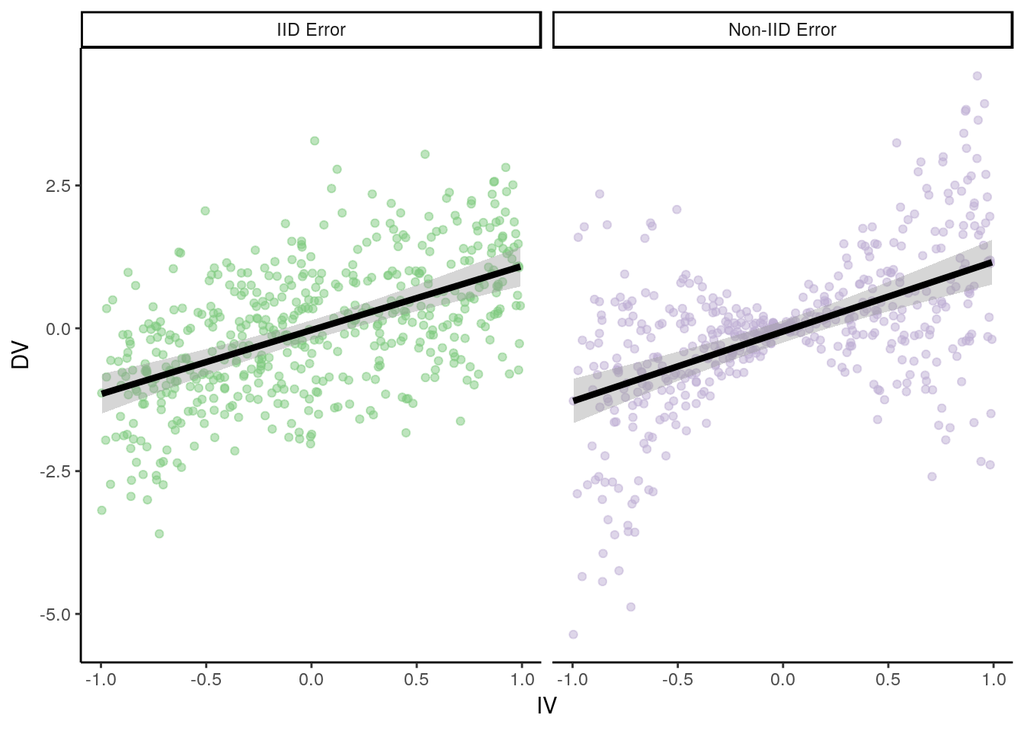

```r
ggplot(parametric_ci_data,
       aes(x=IV, y=DV, color=type)) +
  geom_point(alpha=0.5) +
  geom_smooth(method="lm", se=T, color="black",
              size=1.5, level=0.9999) + # inflating the confidence bands a bit
                                       # to show their distribution is similar
  scale_color_brewer(palette="Accent") +
  facet_wrap(~type) +
  guides(color=F)
```

```r
ggsave("figures/error_dist_non_null.png", width=5, height=3)
```

C.f. Anscombe’s quartet, etc.

```r
summary(lm(DV ~ IV, parametric_ci_data %>% filter(type=="IID Error")))
summary(lm(DV ~ IV, parametric_ci_data %>% filter(type=="Non-IID Error")))
```

```
Call:
lm(formula = DV ~ IV, data = parametric_ci_data %>% filter(type ==
    "IID Error"))

Residuals:
    Min      1Q  Median      3Q     Max
-2.7575 -0.6600 -0.0231  0.6768  3.2956

Coefficients:
            Estimate Std. Error t value Pr(>|t|)
(Intercept) -0.03103    0.04379  -0.709    0.479
IV           1.11977    0.07739  14.470   <2e-16 ***
---
Signif. codes:  0 '***' 0.001 '**' 0.01 '*' 0.05 '.' 0.1 ' ' 1

Residual standard error: 0.9791 on 498 degrees of freedom
Multiple R-squared:  0.296, Adjusted R-squared:  0.2946
F-statistic: 209.4 on 1 and 498 DF,  p-value: < 2.2e-16


Call:
lm(formula = DV ~ IV, data = parametric_ci_data %>% filter(type ==
    "Non-IID Error"))

Residuals:
    Min      1Q  Median      3Q     Max
-4.0872 -0.4030  0.0441  0.5100  3.4718

Coefficients:
            Estimate Std. Error t value Pr(>|t|)
(Intercept) -0.05623    0.04928  -1.141    0.254
IV           1.22127    0.08708  14.024   <2e-16 ***
---
Signif. codes:  0 '***' 0.001 '**' 0.01 '*' 0.05 '.' 0.1 ' ' 1

Residual standard error: 1.102 on 498 degrees of freedom
Multiple R-squared:  0.2831,    Adjusted R-squared:  0.2817
F-statistic: 196.7 on 1 and 498 DF,  p-value: < 2.2e-16
```

```r
ex2_lm_bootstrap_CIs = function(data, R=1000) {
  lm_results = summary(lm(DV ~ IV, data=data))$coefficients
  bootstrap_coefficients = function(data, indices) {
    linear_model = lm(DV ~ IV,
                      data=data[indices,]) # will select a bootstrap sample of the data
    return(linear_model$coefficients)
  }

  boot_results = boot(data=data,
                      statistic=bootstrap_coefficients,
                      R=R)
  boot_intercept_CI = boot.ci(boot_results, index=1, type="bca")
  boot_slope_CI = boot.ci(boot_results, index=2, type="bca")
  return(data.frame(intercept_estimate=lm_results[1, 1],
                    intercept_SE=lm_results[1,2],
                    slope_estimate=lm_results[2, 1],
                    slope_SE=lm_results[2,2],
                    intercept_boot_CI_low=boot_intercept_CI$bca[4],
                    intercept_boot_CI_hi=boot_intercept_CI$bca[5],
                    slope_boot_CI_low=boot_slope_CI$bca[4],
                    slope_boot_CI_hi=boot_slope_CI$bca[5]))
}
```

```r
set.seed(0) # for bootstraps
coefficient_CI_data = parametric_ci_data %>%
  group_by(type) %>%
  do(ex2_lm_bootstrap_CIs(.)) %>%
  ungroup()
```

```r
coefficient_CI_data = coefficient_CI_data %>%
  gather(variable, value, -type) %>%
  separate(variable, c("parameter", "measurement"), extra="merge") %>%
  spread(measurement, value) %>%
  mutate(parametric_CI_low=estimate-1.96*SE,
         parametric_CI_hi=estimate+1.96*SE) %>%
  gather(CI_type, value, contains("CI")) %>%
  separate(CI_type, c("CI_type", "high_or_low"), extra="merge") %>%
  spread(high_or_low, value) %>%
  mutate(CI_type = factor(CI_type))
```

```r
plot_coefficient_CI_data = function(coefficient_CI_data, errorbar_width=0.5) {
  p = ggplot(data=coefficient_CI_data, aes(x=parameter, color=CI_type, y=estimate, ymin=CI_low, ymax=CI_hi)) +
    geom_hline(data=data.frame(parameter=c("intercept", "slope"),
                               estimate=c(true_intercept, true_slope)),
               mapping=aes(yintercept=estimate),
               linetype=3) +
    geom_point(size=2, position=position_dodge(width=0.2)) +
    geom_errorbar(position=position_dodge(width=0.2), width=errorbar_width) +
    facet_grid(~type) +
    scale_y_continuous(breaks=c(0, 0.5, 1), limits=c(-0.2, 1.5)) +
    scale_color_brewer(palette="Dark2", drop=F)
}
```

```r
plot_coefficient_CI_data(coefficient_CI_data)
ggsave("figures/error_dist_CI_example.png", width=5, height=3)

plot_coefficient_CI_data(coefficient_CI_data %>%
                           filter(CI_type=="parametric"),
                         0.25)
ggsave("figures/error_dist_CI_example_parametric_only.png", width=5, height=3)
```

[output not shown]

Challenge Q: Why isn’t the error on the intercept changed in the scaling error case?

This can result in CIs which aren’t actually at the nominal confidence level! And since CIs are equivalent to t-tests in this setting, this can also increase false positive rates. (Also equivalent to Bayesian CrIs.)

```r
num_points = 200
true_intercept = 0
true_slope = 0.
set.seed(0)
parametric_ci_data = data.frame(IV = rep(runif(num_points,  -1, 1), 2),
                                type = rep(c("IID Error", "Non-IID Error"), each=num_points),
                                error = rep(rnorm(num_points, 0, 1), 2)) %>%
  mutate(DV = ifelse(
    type == "IID Error",
    true_slope*IV + error,
    true_slope*IV + 2*abs(IV)*error)) # error increases proportional to distance from 0 on the IV
```

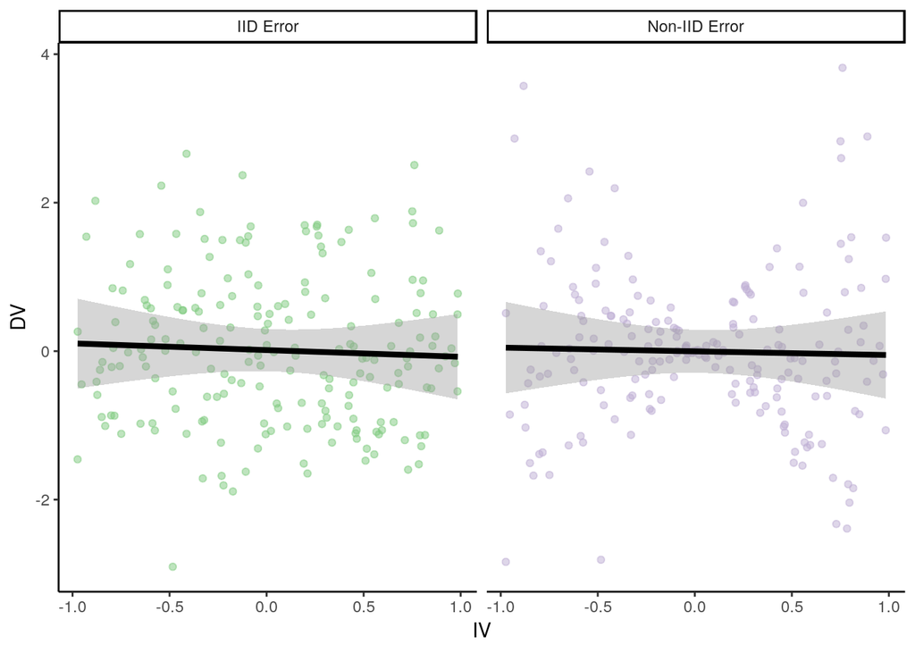

```r
ggplot(parametric_ci_data,
       aes(x=IV, y=DV, color=type)) +
  geom_point(alpha=0.5) +
  geom_smooth(method="lm", se=T, color="black",
              size=1.5, level=0.9999) + # inflating the confidence bands a bit
                                       # to show their distribution is similar
  scale_color_brewer(palette="Accent") +
  facet_wrap(~type) +
  guides(color=F)
```

```r
ggsave("figures/error_dist_null.png", width=5, height=3)
```

```r
error_dist_null_sample = function(num_points) {
  true_intercept = 0
  true_slope = 0
  # We'll sample only for the scaling error case, we know IID works
  this_data = data.frame(IV = runif(num_points,  -1, 1),
                         error = rnorm(num_points, 0, 1)) %>%
    mutate(DV = true_slope*IV + 2*abs(IV)*error) # error increases proportional to distance from 0 on the IV

  coefficient_CI_data = ex2_lm_bootstrap_CIs(this_data,
                                             R=500) # take fewer bootstrap samples, to speed things up

  coefficient_CI_data = coefficient_CI_data %>%
    gather(variable, value) %>%
    separate(variable, c("parameter", "measurement"), extra="merge") %>%
    spread(measurement, value) %>%
    mutate(parametric_CI_low=estimate-1.96*SE,
           parametric_CI_hi=estimate+1.96*SE) %>%
    gather(CI_type, value, contains("CI")) %>%
    separate(CI_type, c("CI_type", "high_or_low"), extra="merge") %>%
    spread(high_or_low, value) %>%
    mutate(significant = sign(CI_hi) == sign(CI_low)) %>%
    select(parameter, CI_type, significant)
  return(list(coefficient_CI_data))
}
```

```r
num_simulations = 500
num_points = 200
set.seed(0)
noise_dist_simulation_results = replicate(num_simulations, error_dist_null_sample(num_points)) %>%
  bind_rows()
```

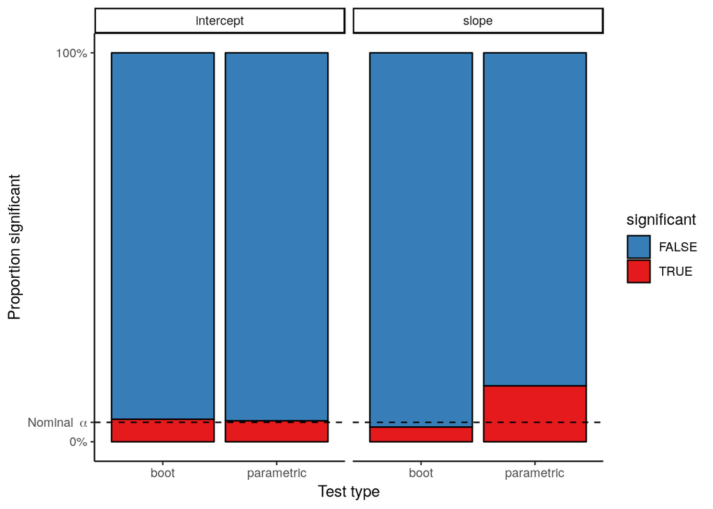

```r
ggplot(noise_dist_simulation_results, aes(x=CI_type, fill=significant)) +
  geom_bar(stat="count", color="black") +
  scale_fill_brewer(palette="Set1", direction=-1) +
  facet_wrap(~parameter) +
  scale_y_continuous(breaks=c(0, 0.05*num_simulations, num_simulations),
                     labels=c("0%", expression(Nominal ~ alpha), "100%")) +
  labs(x="Test type",
       y="Proportion significant") +
  geom_hline(yintercept=0.05*num_simulations, linetype=2)
```

```r
ggsave("figures/error_dist_proportion_significant.png", width=5, height=3)
```

```r
noise_dist_simulation_results %>%
  count(parameter, CI_type, significant) %>%
  mutate(prop=n/num_simulations)
```

```
# A tibble: 8 x 5
  parameter CI_type    significant     n  prop
  <chr>     <chr>      <lgl>       <int> <dbl>
1 intercept boot       FALSE         471 0.942
2 intercept boot       TRUE           29 0.058
3 intercept parametric FALSE         473 0.946
4 intercept parametric TRUE           27 0.054
5 slope     boot       FALSE         481 0.962
6 slope     boot       TRUE           19 0.038
7 slope     parametric FALSE         428 0.856
8 slope     parametric TRUE           72 0.144
```

False positive rate nearly triples for the parametric model!

### 15.2.3 Density estimate conceptual plot

```r
density_similarity_conceptual_plot_data = expand.grid(x=seq(0, 4, 0.01),
                                                      y=seq(0, 4, 0.01)) %>%
  mutate(population_1 = exp(-((x-2)^2 +(y-3)^2)/8) * exp(-((x-2/y)^2 +(y-1/x)^2)/2), #These are definitely not proper distributions
         population_2 = exp(-((x)^2 +(y)^2)/8) * exp(-((x/2)^2 +(y/2-1/x)^2)/2)) %>%
  gather(population, value, contains("population"))
```

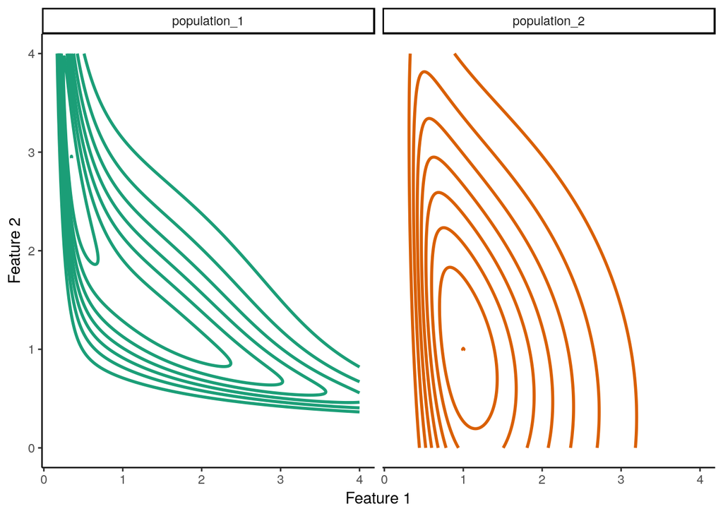

```r
ggplot(density_similarity_conceptual_plot_data,
       aes(x=x, y=y, z=value, color=population)) +
  geom_contour(size=1, bins=8) +
  scale_color_brewer(palette="Dark2") +
  facet_wrap(~population) +
  labs(x = "Feature 1", y="Feature 2") +
  guides(color=F)
```

```r
ggsave("figures/conceptual_density_plot.png", width=5, height=3)
```

## 15.3 Bootstrap resampling

### 15.3.1 Demo

```r
num_points = 100
true_intercept = 0
true_slope = 1.
set.seed(2) # I p-hacked the shit out of this demo to make the ideas more clear
parametric_ci_data = data.frame(IV = rep(runif(num_points,  -1, 1), 2),
                                type = rep(c("IID Error", "Scaling Error"), each=num_points),
                                error = rep(rnorm(num_points, 0, 1), 2)) %>%
  mutate(DV = ifelse(
    type == "IID Error",
    true_slope*IV + error,
    true_slope*IV + 2*abs(IV)*error)) # error increases proportional to distance from 0 on the IV
```

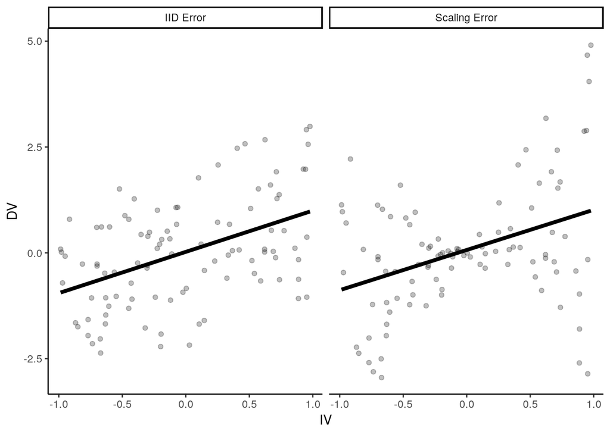

```r
p = ggplot(parametric_ci_data,
       aes(x=IV, y=DV)) +
  geom_point(alpha=0.25) +
  geom_smooth(method="lm", se=F, color="black",
              size=1.5) +
  facet_wrap(~type)
p
```

```r
ggsave("figures/bootstrap_demo_0.png", width=5, height=3)
```

```r
set.seed(15) # See above RE: p-hacking
samp_1_indices = sample(2:num_points, num_points, replace=T)
samp_1 = parametric_ci_data[c(samp_1_indices, samp_1_indices+num_points), ] # take the same rows from each type of data
set.seed(2) # See above RE: p-hacking
samp_2_indices = sample(1:num_points, num_points, replace=T)
samp_2 = parametric_ci_data[c(samp_2_indices, samp_2_indices+num_points), ]

many_samples_indices = sample(1:num_points, 8*num_points, replace=T)
many_samples = bind_rows(samp_1 %>%
                           mutate(sample=1),
                         samp_2 %>% mutate(sample=2),
                         parametric_ci_data[c(many_samples_indices, many_samples_indices+num_points),] %>%
                           mutate(sample=rep(rep(3:10, each=num_points), 2)))
```

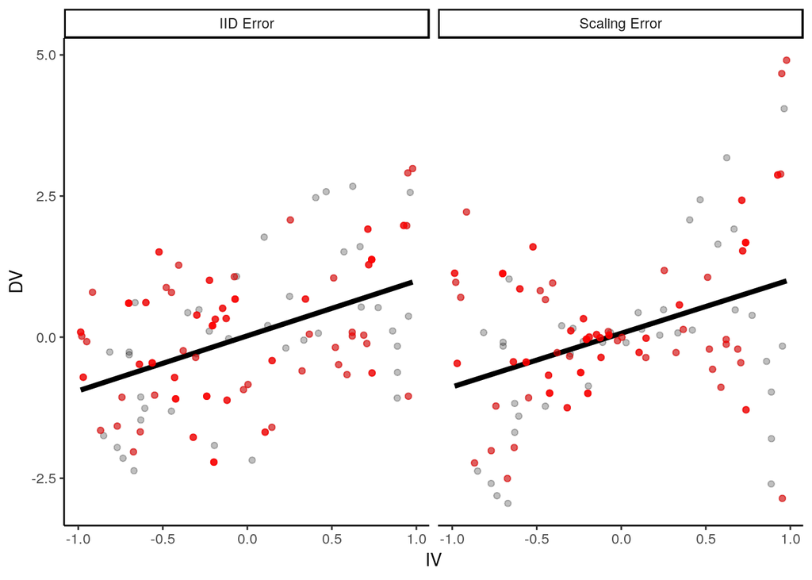

```r
p +
  geom_point(data=samp_1,
             aes(color=NA), color="red", alpha=0.5)
```

```r
ggsave("figures/bootstrap_demo_1.png", width=5, height=3)
```

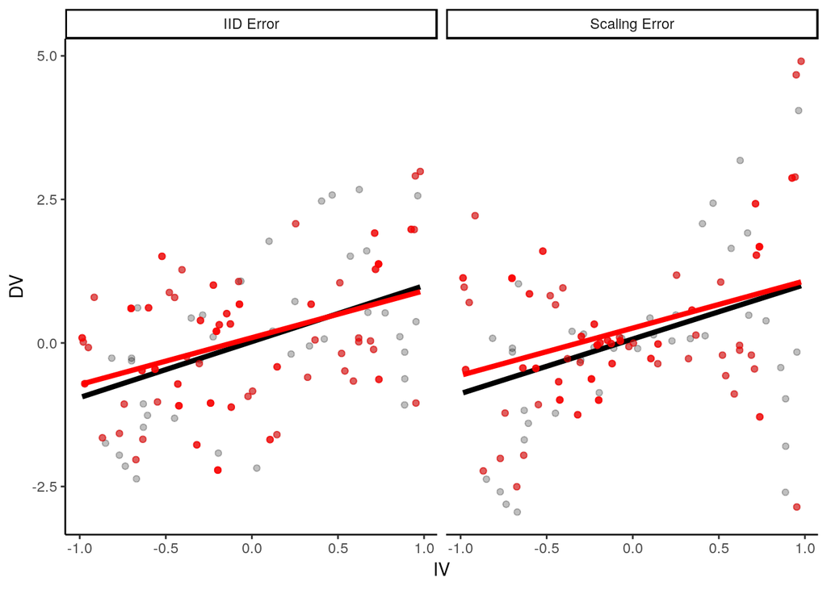

```r
p +
  geom_point(data=samp_1,
             aes(color=NA), color="red", alpha=0.5) +
  geom_smooth(data=samp_1,
              method="lm", se=F, color="red",
              size=1.5)
```

```r
ggsave("figures/bootstrap_demo_2.png", width=5, height=3)
```

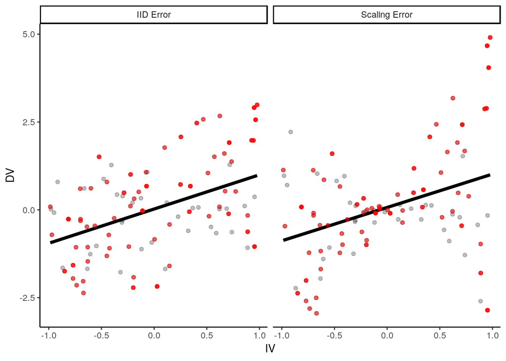

```r
p +
  geom_point(data=samp_2,
             aes(color=NA), color="red", alpha=0.5)
```

```r
ggsave("figures/bootstrap_demo_3.png", width=5, height=3)
```

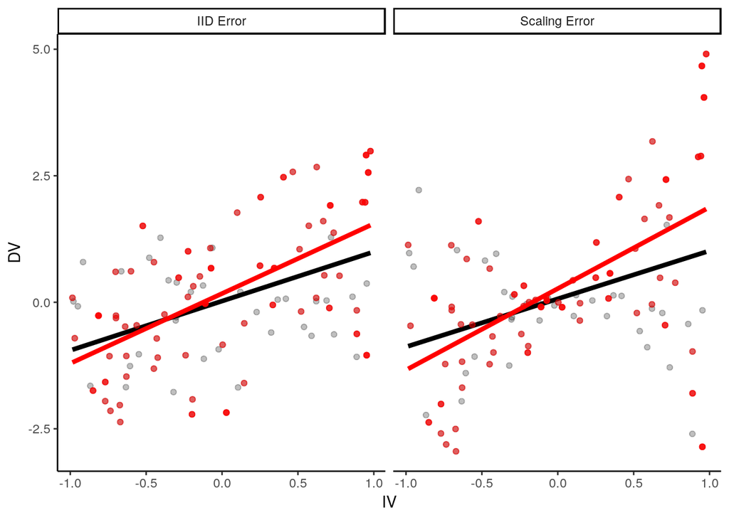

```r
p +
  geom_point(data=samp_2,
             aes(color=NA), color="red", alpha=0.5) +
  geom_smooth(data=samp_2,
              method="lm", se=F, color="red",
              size=1.5)
```

```r
ggsave("figures/bootstrap_demo_4.png", width=5, height=3)
```

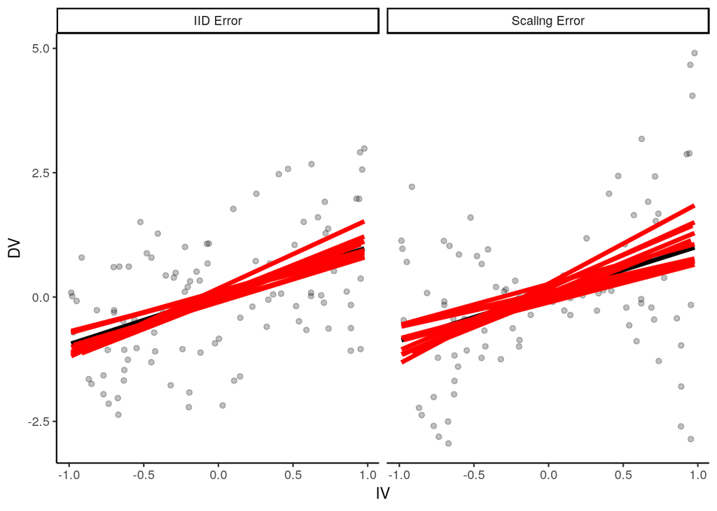

```r
p +
  geom_smooth(data=many_samples,
              aes(group=sample),
              method="lm", se=F,
              size=1.5,
              color="red")
```

```r
ggsave("figures/bootstrap_demo_5.png", width=5, height=3)
```

## 15.4 Applications

### 15.4.1 Bootstrap confidence intervals

```r
num_top_points = 23
num_mid_points = 4
num_outlier_points = 2
max_score = 100
set.seed(0)
test_score_data = data.frame(
  score=c(rbinom(num_top_points, max_score, 0.9999), rbinom(num_mid_points, max_score, 0.97), sample(0:max_score, num_outlier_points, replace=T)),
  type="Observed sample"
)
```

```r
get_mean_score = function(data, indices) {
  return(mean(data[indices,]$score))
}

bootstrap_results = boot(test_score_data, get_mean_score, R=1000)
bootstrap_CIs = boot.ci(bootstrap_results)
bootstrap_CIs
```

```
BOOTSTRAP CONFIDENCE INTERVAL CALCULATIONS
Based on 1000 bootstrap replicates

CALL :
boot.ci(boot.out = bootstrap_results)

Intervals :
Level      Normal              Basic
95%   ( 86.53, 101.70 )   ( 88.38, 103.00 )

Level     Percentile            BCa
95%   (85.21, 99.83 )   (80.66, 99.59 )
Calculations and Intervals on Original Scale
Some BCa intervals may be unstable
```

```r
test_summary_data = test_score_data %>%
  summarise(mean=mean(score),
            se=sd(score)/sqrt(n()),
            parametric_CI_low=mean-1.96*se,
            parametric_CI_high=mean+1.96*se)

test_score_data = test_score_data %>%
  bind_rows(
    data.frame(score=bootstrap_results$t, type="Boot. sampling dist.")
  )  %>%
  mutate(type=factor(type, levels=c("Observed sample", "Boot. sampling dist.")))
test_summary_data = test_summary_data %>%
  mutate(type = factor("Boot. sampling dist.", levels=levels(test_score_data$type)),
         percentile_CI_low=bootstrap_CIs$percent[4],
         percentile_CI_high=bootstrap_CIs$percent[5],
         bca_CI_low=bootstrap_CIs$bca[4],
         bca_CI_high=bootstrap_CIs$bca[5]) %>%
  gather(CI_type, value, contains("CI")) %>%
  separate(CI_type, c("CI_type", "endpoint"), extra="merge") %>%
  spread(endpoint, value) %>%
  mutate(y=c(170, 210, 190),
         CI_type=factor(CI_type, levels=c("parametric", "percentile", "bca"), labels=c("Normal", "Boot: %", "Boot: BCA")))
```

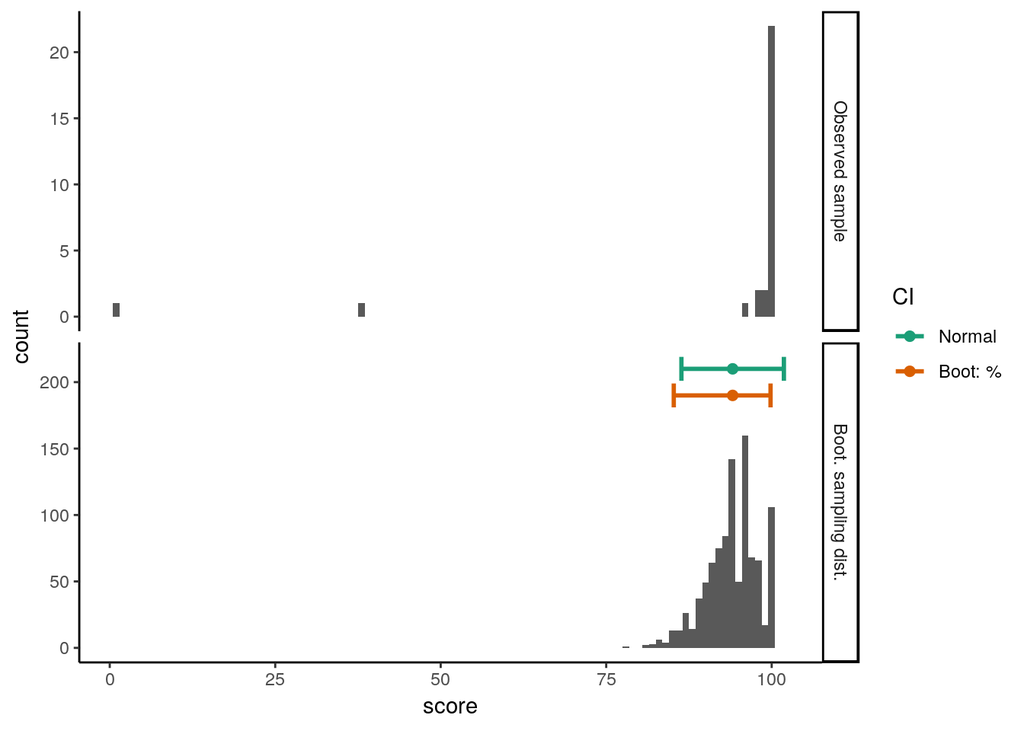

```r
ggplot(test_summary_data %>%
             filter(CI_type != "Boot: BCA"), aes(x=score)) +
  geom_histogram(data=test_score_data,
                 binwidth=1) +
  geom_point(mapping=aes(x=mean, y=y, color=CI_type),
             size=2) +
  geom_errorbarh(mapping=aes(y=y, color=CI_type, xmin=CI_low, x=NULL, xmax=CI_high),
                 size=1,
                 position=position_dodge()) +
  facet_grid(type ~ ., scales="free_y")+
  scale_color_brewer(palette="Dark2") +
  guides(color=guide_legend(title="CI"))
```

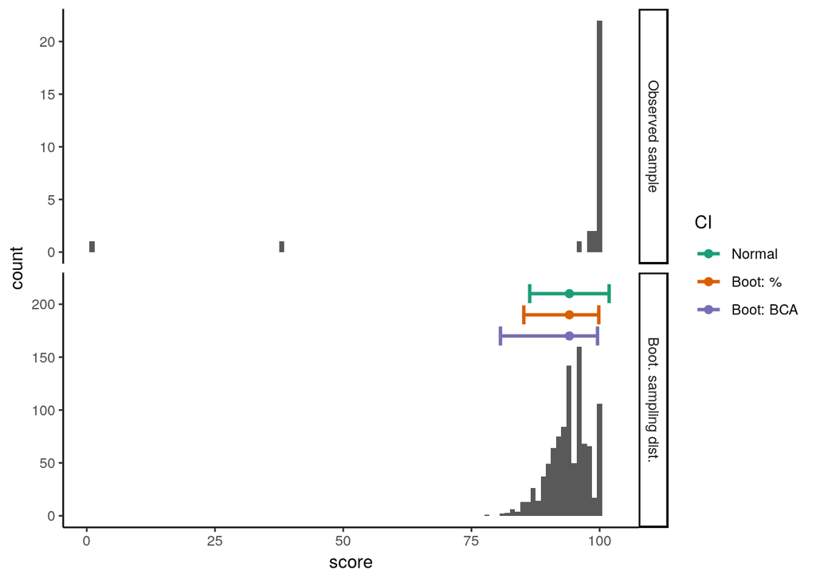

```r
ggsave("figures/bootstrap_CI_0.png", width=5, height=3)
ggplot(test_summary_data, aes(x=score)) +
  geom_histogram(data=test_score_data,
                 binwidth=1) +
  geom_point(mapping=aes(x=mean, y=y, color=CI_type),
             size=2) +
  geom_errorbarh(mapping=aes(y=y, color=CI_type, xmin=CI_low, x=NULL, xmax=CI_high),
                 size=1,
                 position=position_dodge()) +
  facet_grid(type ~ ., scales="free_y")+
  scale_color_brewer(palette="Dark2") +
  guides(color=guide_legend(title="CI"))
ggsave("figures/bootstrap_CI_1.png", width=5, height=3)
```

### 15.4.2 Bootstrap (& permutation) hypothesis tests

```r
num_flips = 20
true_heads_prob = 0.9
set.seed(2)
flips = rbinom(num_flips, 1, true_heads_prob)
flip_data = data.frame(flip_result = factor(flips, labels=c("Tails", "Heads")))
```

```r
flip_data_plot = ggplot(data = flip_data, aes(x = flips, fill = flips)) +
  geom_dotplot(binwidth=0.03) +
  scale_x_continuous(breaks = c(0, 1),
                     labels = c("tails", "heads")) +
  scale_y_continuous(breaks=c()) +
  labs(x="Flip result", y="")
```

```r
get_mean_heads = function(data, indices) {
  return(mean(data[indices, "flip_result"] == "Heads"))
}

set.seed(0)
bootstrap_results = boot(flip_data, get_mean_heads, R=20000)
bootstrap_CIs = boot.ci(bootstrap_results)
bootstrap_CIs
```

```
BOOTSTRAP CONFIDENCE INTERVAL CALCULATIONS
Based on 20000 bootstrap replicates

CALL :
boot.ci(boot.out = bootstrap_results)

Intervals :
Level      Normal              Basic
95%   ( 0.6940,  1.0061 )   ( 0.7000,  1.0000 )

Level     Percentile            BCa
95%   ( 0.70,  1.00 )   ( 0.55,  0.95 )
Calculations and Intervals on Original Scale
```

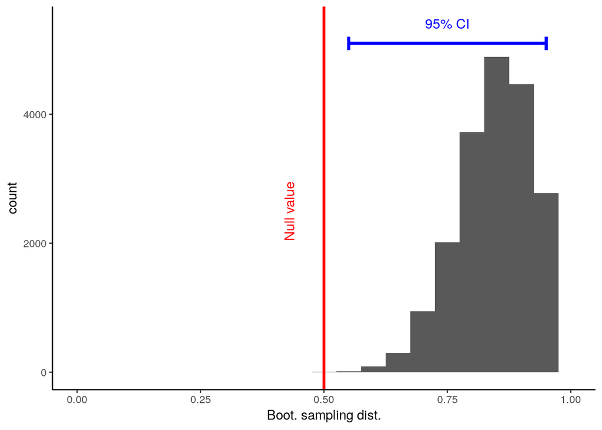

```r
flip_boot_plot = ggplot(data=data.frame(mean_flips=bootstrap_results$t),
                        aes(x=mean_flips)) +
  geom_histogram(binwidth=0.05) +
  xlim(0, 1) +
  geom_vline(xintercept=0.5,
             color="red",
             size=1.1) +
  annotate("text",
           label="Null value",
           color="red",
           x=0.43, y=2500,
           angle=90,
           size=4) +
  annotate("text",
           label="95% CI",
           color="blue",
           x=0.75, y=5400,
           size=4) +
  geom_errorbarh(aes(xmin=bootstrap_CIs$bca[4],
                    xmax=bootstrap_CIs$bca[5],
                    y=5100),
                 color="blue",
                 size=1.1,
                 height=200) +
  labs(x="Boot. sampling dist.")

flip_boot_plot
```

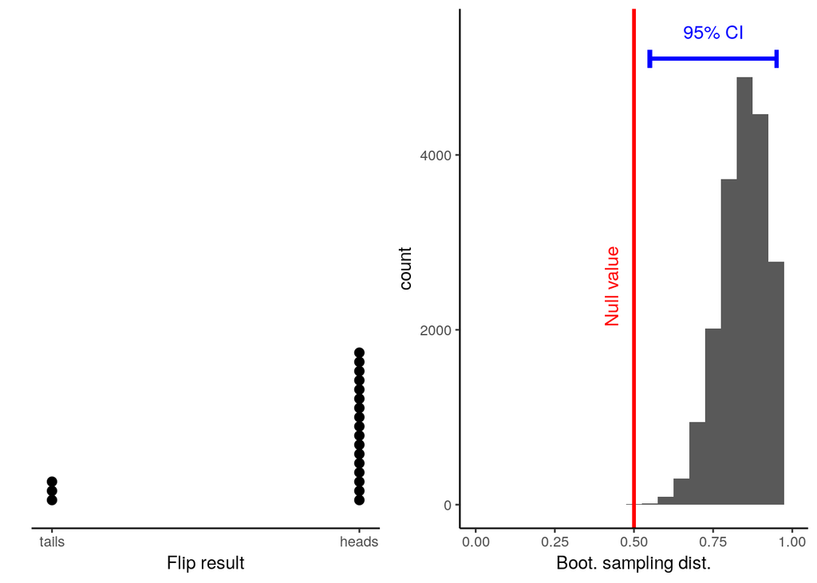

```r
flip_data_plot + flip_boot_plot +
  plot_layout()
ggsave("figures/bootstrap_test.png", width=5, height=2.5)
```

```r
bootstrap_CIs = boot.ci(bootstrap_results,
                        conf=0.999)
```

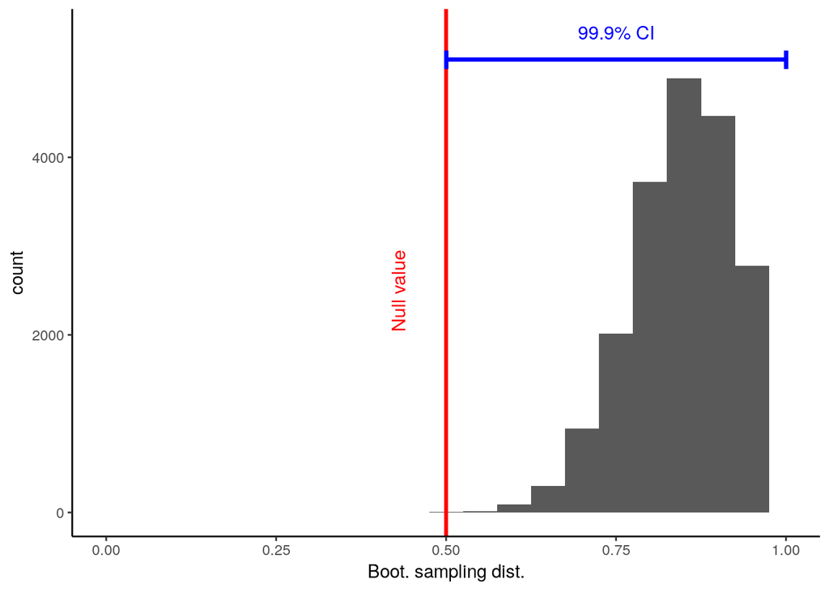

```r
flip_boot_plot = ggplot(data=data.frame(mean_flips=bootstrap_results$t),
                        aes(x=mean_flips)) +
  geom_histogram(binwidth=0.05) +
  xlim(0, 1) +
  geom_vline(xintercept=0.5,
             color="red",
             size=1.1) +
  annotate("text",
           label="Null value",
           color="red",
           x=0.43, y=2500,
           angle=90,
           size=4) +
  annotate("text",
           label="99.9% CI",
           color="blue",
           x=0.75, y=5400,
           size=4) +
  geom_errorbarh(aes(xmin=bootstrap_CIs$bca[4],
                    xmax=bootstrap_CIs$bca[5],
                    y=5100),
                 color="blue",
                 size=1.1,
                 height=200) +
  labs(x="Boot. sampling dist.")

flip_boot_plot
```

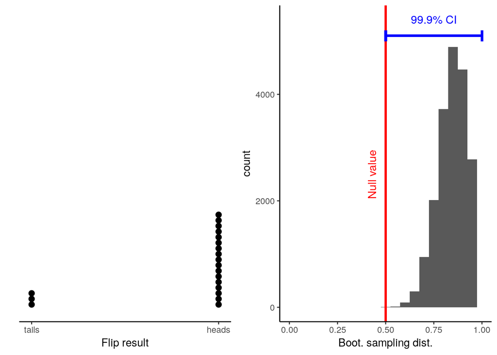

```r
flip_data_plot + flip_boot_plot +
  plot_layout()
ggsave("figures/bootstrap_test_999.png", width=5, height=2.5)
```

Canty, Angelo, and Brian Ripley. 2017. *Boot: Bootstrap Functions (Originally by Angelo Canty for S)*. https://CRAN.R-project.org/package=boot.

Henry, Lionel, and Hadley Wickham. 2018. *Purrr: Functional Programming Tools*. https://CRAN.R-project.org/package=purrr.

Müller, Kirill, and Hadley Wickham. 2019. *Tibble: Simple Data Frames*. https://CRAN.R-project.org/package=tibble.

Pedersen, Thomas Lin. 2017. *Patchwork: The Composer of Ggplots*. https://github.com/thomasp85/patchwork.

R Core Team. 2018. *R: A Language and Environment for Statistical Computing*. Vienna, Austria: R Foundation for Statistical Computing. https://www.R-project.org/.

Wickham, Hadley. 2017. *Tidyverse: Easily Install and Load the ’Tidyverse’*. https://CRAN.R-project.org/package=tidyverse.

———. 2018a. *Forcats: Tools for Working with Categorical Variables (Factors)*. https://CRAN.R-project.org/package=forcats.

———. 2018b. *Stringr: Simple, Consistent Wrappers for Common String Operations*. https://CRAN.R-project.org/package=stringr.

Wickham, Hadley, and Lionel Henry. 2018. *Tidyr: Easily Tidy Data with ’Spread()’ and ’Gather()’ Functions*. https://CRAN.R-project.org/package=tidyr.

Wickham, Hadley, Winston Chang, Lionel Henry, Thomas Lin Pedersen, Kohske Takahashi, Claus Wilke, and Kara Woo. 2018. *Ggplot2: Create Elegant Data Visualisations Using the Grammar of Graphics*. https://CRAN.R-project.org/package=ggplot2.

Wickham, Hadley, Romain François, Lionel Henry, and Kirill Müller. 2018. *Dplyr: A Grammar of Data Manipulation*. https://CRAN.R-project.org/package=dplyr.

Wickham, Hadley, Jim Hester, and Romain Francois. 2017. *Readr: Read Rectangular Text Data*. https://CRAN.R-project.org/package=readr.